# Model Selection

Jonathan Cárdenas

2023-03-12

# 1. Dataset upload and data set splitting

Uploading the original dataset (raw data):

```r
raw_data<- read.csv("harvest_complete.csv")
raw_data$treatment <-as.factor(with(raw_data, ifelse(tray_id == '1', '280 ppm',
                                                     ifelse(tray_id == 2, '160 ppm', '80 ppm'))))
```

## 1.1 Separate dataset to use image derived features as predictors.

```r
img_predictors <- raw_data %>% dplyr::select(12:24) #1
manual_predictors <- raw_data %>% dplyr::select(1,3,7,9:12,25) #2
img_LFW <- raw_data %>% dplyr::select(7,12:23) #3
img_LDW <- raw_data %>% dplyr::select(8,12:23) #4
img_LA <- raw_data %>% dplyr::select(7,8,9,12:23) #5
```

# 2. Model Selection and Performance

## Model 0: Multiple Linear Regression.

### Estimation of Leaf Fresh Weight (LFW)

```r
# Fitting null & full model to use step AIC in order to select the best variables (we wabt to optimize model fit and model complexity).

full_LFW<- lm(LFW_g~., data = img_LFW)
null_LFW<- lm(LFW_g~1, data = img_LFW)

linear_mod<-stepAIC(null_LFW,direction = 'forward', scope = list(upper=full_LFW,lower = null_LFW))
```

```
## Start:  AIC=1337.26
## LFW_g ~ 1
##
##                              Df Sum of Sq    RSS     AIC
## + plant_ellipse_minor_axis    1    498073  41458  915.87
## + height_mm                   1    489314  50217  947.50
## + plant_area                  1    466937  72594 1008.30
## + plant_height                1    463135  76396 1016.73
## + plant_width                 1    437259 102272 1064.86
## + plant_convex_hull_area      1    430538 108993 1075.36
## + plant_longest_path          1    420483 119048 1089.92
## + plant_ellipse_major_axis    1    417716 121815 1093.71
## + plant_convex_hull_vertices  1    405459 134072 1109.53
## + plant_perimeter             1    353613 185918 1163.47
## + plant_solidity              1     62080 477451 1319.09
## <none>                                    539531 1337.26
## + plant_ellipse_angle         1        87 539444 1339.24
##
## Step:  AIC=915.87
## LFW_g ~ plant_ellipse_minor_axis
##
##                              Df Sum of Sq   RSS    AIC
## + height_mm                   1    3210.8 38248 904.57
## + plant_area                  1    2504.9 38953 907.59
## + plant_solidity              1    1068.4 40390 913.56
## + plant_convex_hull_area      1     819.4 40639 914.58
## <none>                                    41458 915.87
## + plant_perimeter             1     408.6 41050 916.24
## + plant_ellipse_angle         1     290.1 41168 916.71
## + plant_convex_hull_vertices  1     119.7 41339 917.39
## + plant_height                1     100.0 41358 917.47
## + plant_width                 1      31.4 41427 917.75
## + plant_longest_path          1       0.8 41457 917.87
## + plant_ellipse_major_axis    1       0.1 41458 917.87
##
## Step:  AIC=904.57
## LFW_g ~ plant_ellipse_minor_axis + height_mm
##
##                              Df Sum of Sq   RSS    AIC
## + plant_area                  1    4572.0 33676 885.57
```

[output cut: 51 more lines]

```
## + plant_width                 1    31.282 18408 791.91
## + plant_ellipse_angle         1     2.109 18437 792.17
##
## Step:  AIC=790.03
## LFW_g ~ plant_ellipse_minor_axis + height_mm + plant_area + plant_ellipse_major_axis +
##     plant_solidity + plant_convex_hull_area
##
##                              Df Sum of Sq   RSS    AIC
## <none>                                    18199 790.03
## + plant_longest_path          1    75.939 18123 791.34
## + plant_convex_hull_vertices  1    31.138 18168 791.74
## + plant_perimeter             1    26.694 18173 791.78
## + plant_height                1    13.573 18186 791.90
## + plant_width                 1     1.150 18198 792.02
## + plant_ellipse_angle         1     0.600 18199 792.02
```

```r
# Here, we are storing the optimized linear model in a variable called linear_mod.
```

```r
summary(linear_mod)
```

```
##
## Call:
## lm(formula = LFW_g ~ plant_ellipse_minor_axis + height_mm + plant_area +
##     plant_ellipse_major_axis + plant_solidity + plant_convex_hull_area,
##     data = img_LFW)
##
## Residuals:
##     Min      1Q  Median      3Q     Max
## -32.374  -6.050  -0.374   5.492  40.812
##
## Coefficients:
##                            Estimate Std. Error t value Pr(>|t|)
## (Intercept)               2.106e+01  1.814e+01   1.161   0.2475
## plant_ellipse_minor_axis -1.050e-01  9.547e-02  -1.100   0.2730
## height_mm                 7.821e+00  8.890e-01   8.797 2.29e-15 ***
## plant_area                8.083e-03  1.061e-03   7.621 2.19e-12 ***
## plant_ellipse_major_axis -7.442e-01  8.310e-02  -8.956 8.88e-16 ***
## plant_solidity           -4.195e+01  1.924e+01  -2.180   0.0307 *
## plant_convex_hull_area   -1.202e-03  8.323e-04  -1.444   0.1507
## ---
## Signif. codes:  0 '***' 0.001 '**' 0.01 '*' 0.05 '.' 0.1 ' ' 1
##
## Residual standard error: 10.73 on 158 degrees of freedom
## Multiple R-squared:  0.9663, Adjusted R-squared:  0.965
## F-statistic: 754.3 on 6 and 158 DF,  p-value: < 2.2e-16
```

After checking the coefficients p-value,looks like is possible to discard more predictors that are not so significant (plant_ellipse_minor_axis, plant_convex_hull_area). The model shown here discards three variables that are not significant according to the coefficient p-value. However, our models performance gets worse.

```r
opt_LFW_linear <- lm(LFW_g ~ height_mm + plant_area +
    plant_ellipse_major_axis,
    data = img_LFW)

summary(opt_LFW_linear)
```

```
##
## Call:
## lm(formula = LFW_g ~ height_mm + plant_area + plant_ellipse_major_axis,
##     data = img_LFW)
##
## Residuals:
##     Min      1Q  Median      3Q     Max
## -31.333  -6.653  -0.889   5.545  40.966
##
## Coefficients:
##                            Estimate Std. Error t value Pr(>|t|)
## (Intercept)              -1.682e+01  5.155e+00  -3.262  0.00135 **
## height_mm                 7.346e+00  4.292e-01  17.116  < 2e-16 ***
## plant_area                6.165e-03  4.075e-04  15.129  < 2e-16 ***
## plant_ellipse_major_axis -7.184e-01  6.184e-02 -11.617  < 2e-16 ***
## ---
## Signif. codes:  0 '***' 0.001 '**' 0.01 '*' 0.05 '.' 0.1 ' ' 1
##
## Residual standard error: 10.82 on 161 degrees of freedom
## Multiple R-squared:  0.965,  Adjusted R-squared:  0.9644
## F-statistic:  1481 on 3 and 161 DF,  p-value: < 2.2e-16
```

### Estimation of Leaf Dry Weight (LDW)

```r
# Fitting null & full model to use step AIC in order to select the best variables (we wabt to optimize model fit and model complexity).

full_LDW<- lm(LDW_g~., data = img_LDW)
null_LDW<- lm(LDW_g~1, data = img_LDW)
linear_LDW<-stepAIC(null_LDW,direction = 'forward', scope = list(upper=full_LDW,lower = null_LDW))
```

```
## Start:  AIC=316.6
## LDW_g ~ 1
##
##                              Df Sum of Sq     RSS     AIC
## + plant_ellipse_minor_axis    1   1046.42   64.13 -151.94
## + height_mm                   1   1028.79   81.76 -111.86
## + plant_height                1    971.92  138.63  -24.74
## + plant_area                  1    965.40  145.14  -17.16
## + plant_width                 1    915.64  194.91   31.48
## + plant_convex_hull_area      1    890.41  220.14   51.57
## + plant_longest_path          1    878.47  232.07   60.28
## + plant_ellipse_major_axis    1    872.22  238.33   64.67
## + plant_convex_hull_vertices  1    856.43  254.12   75.25
## + plant_perimeter             1    744.78  365.76  135.35
## + plant_solidity              1    126.37  984.17  298.67
## <none>                                    1110.55  316.60
## + plant_ellipse_angle         1      0.02 1110.52  318.60
##
## Step:  AIC=-151.94
## LDW_g ~ plant_ellipse_minor_axis
##
##                              Df Sum of Sq    RSS     AIC
## + height_mm                   1    7.0160 57.111 -169.06
## + plant_area                  1    2.3381 61.789 -156.07
## + plant_solidity              1    1.7167 62.410 -154.42
## <none>                                    64.127 -151.94
## + plant_perimeter             1    0.7399 63.387 -151.85
## + plant_convex_hull_area      1    0.5381 63.589 -151.33
## + plant_height                1    0.2793 63.848 -150.66
## + plant_ellipse_angle         1    0.2584 63.868 -150.60
## + plant_width                 1    0.1619 63.965 -150.36
## + plant_convex_hull_vertices  1    0.0983 64.028 -150.19
## + plant_longest_path          1    0.0635 64.063 -150.10
## + plant_ellipse_major_axis    1    0.0465 64.080 -150.06
##
## Step:  AIC=-169.06
## LDW_g ~ plant_ellipse_minor_axis + height_mm
##
##                              Df Sum of Sq    RSS     AIC
## + plant_area                  1    5.3814 51.729 -183.39
```

[output cut: 24 more lines]

```
## + plant_convex_hull_vertices  1    0.0066 51.723 -181.41
##
## Step:  AIC=-262.69
## LDW_g ~ plant_ellipse_minor_axis + height_mm + plant_area + plant_ellipse_major_axis
##
##                              Df Sum of Sq    RSS     AIC
## <none>                                    31.605 -262.69
## + plant_solidity              1   0.35931 31.245 -262.57
## + plant_convex_hull_vertices  1   0.24923 31.355 -261.99
## + plant_longest_path          1   0.14430 31.460 -261.44
## + plant_height                1   0.09109 31.514 -261.16
## + plant_convex_hull_area      1   0.05827 31.546 -260.99
## + plant_width                 1   0.05572 31.549 -260.98
## + plant_ellipse_angle         1   0.00419 31.601 -260.71
## + plant_perimeter             1   0.00168 31.603 -260.69
```

```r
# Here, we are storing the optimized linear model in a variable called linear_mod.
```

```r
summary(linear_LDW)
```

```
##
## Call:
## lm(formula = LDW_g ~ plant_ellipse_minor_axis + height_mm + plant_area +
##     plant_ellipse_major_axis, data = img_LDW)
##
## Residuals:
##      Min       1Q   Median       3Q      Max
## -1.14037 -0.29357  0.00617  0.21747  1.66202
##
## Coefficients:
##                            Estimate Std. Error t value Pr(>|t|)
## (Intercept)              -1.091e+00  2.119e-01  -5.147 7.67e-07 ***
## plant_ellipse_minor_axis  3.626e-03  3.896e-03   0.931    0.353
## height_mm                 3.320e-01  3.539e-02   9.383  < 2e-16 ***
## plant_area                2.322e-04  2.044e-05  11.359  < 2e-16 ***
## plant_ellipse_major_axis -2.706e-02  2.680e-03 -10.094  < 2e-16 ***
## ---
## Signif. codes:  0 '***' 0.001 '**' 0.01 '*' 0.05 '.' 0.1 ' ' 1
##
## Residual standard error: 0.4444 on 160 degrees of freedom
## Multiple R-squared:  0.9715, Adjusted R-squared:  0.9708
## F-statistic:  1366 on 4 and 160 DF,  p-value: < 2.2e-16
```

### Estimation of Leaf Area (LA)

Notice that for Leaf Area(LA) we are including both LFW and LDW as predictors.

```r
# Fitting null & full model to use step AIC in order to select the best variables (we wabt to optimize model fit and model complexity).

full_LA<- lm(LA_mm2~., data = img_LA)
null_LA<- lm(LA_mm2~1, data = img_LA)
linear_LA<-stepAIC(null_LA,direction = 'forward', scope = list(upper=full_LA,lower = null_LA))
```

```
## Start:  AIC=2145.46
## LA_mm2 ~ 1
##
##                              Df Sum of Sq      RSS    AIC
## + LDW_g                       1  72167588   151587 1129.8
## + LFW_g                       1  72028689   290486 1237.1
## + plant_ellipse_minor_axis    1  67685392  4633782 1694.1
## + height_mm                   1  67015000  5304175 1716.4
## + plant_height                1  62728369  9590806 1814.1
## + plant_area                  1  62414450  9904724 1819.4
## + plant_width                 1  58987963 13331211 1868.5
## + plant_convex_hull_area      1  57462148 14857027 1886.3
## + plant_longest_path          1  56605612 15713563 1895.6
## + plant_ellipse_major_axis    1  56220730 16098445 1899.6
## + plant_convex_hull_vertices  1  55547596 16771578 1906.3
## + plant_perimeter             1  47744139 24575036 1969.4
## + plant_solidity              1   8378844 63940331 2127.1
## <none>                                    72319175 2145.5
## + plant_ellipse_angle         1      3611 72315563 2147.4
##
## Step:  AIC=1129.79
## LA_mm2 ~ LDW_g
##
##                              Df Sum of Sq    RSS    AIC
## + LFW_g                       1   27808.3 123779 1098.3
## + plant_perimeter             1    6769.5 144817 1124.2
## + plant_width                 1    6348.9 145238 1124.7
## + plant_ellipse_minor_axis    1    6331.7 145255 1124.8
## + plant_height                1    5902.0 145685 1125.2
## + plant_longest_path          1    4870.4 146716 1126.4
## + plant_ellipse_major_axis    1    4358.1 147229 1127.0
## + plant_convex_hull_area      1    3501.1 148086 1127.9
## + plant_area                  1    3153.5 148433 1128.3
## <none>                                    151587 1129.8
## + height_mm                   1    1304.3 150283 1130.4
## + plant_solidity              1     943.6 150643 1130.8
## + plant_ellipse_angle         1     428.3 151159 1131.3
## + plant_convex_hull_vertices  1     223.0 151364 1131.5
##
## Step:  AIC=1098.35
```

[output cut: 34 more lines]

```
## Step:  AIC=1073.16
## LA_mm2 ~ LDW_g + LFW_g + height_mm + plant_width
##
##                              Df Sum of Sq    RSS    AIC
## <none>                                    103711 1073.2
## + plant_ellipse_minor_axis    1   1021.49 102690 1073.5
## + plant_ellipse_major_axis    1    573.96 103137 1074.2
## + plant_area                  1    417.52 103294 1074.5
## + plant_convex_hull_area      1    330.01 103381 1074.6
## + plant_height                1    200.06 103511 1074.8
## + plant_longest_path          1    103.27 103608 1075.0
## + plant_ellipse_angle         1    101.01 103610 1075.0
## + plant_convex_hull_vertices  1     46.47 103665 1075.1
## + plant_solidity              1     23.61 103688 1075.1
## + plant_perimeter             1      5.91 103705 1075.2
```

```r
# Here, we are storing the optimized linear model in a variable called linear_mod.
```

```r
summary(linear_LA)
```

```
##
## Call:
## lm(formula = LA_mm2 ~ LDW_g + LFW_g + height_mm + plant_width,
##     data = img_LA)
##
## Residuals:
##     Min      1Q  Median      3Q     Max
## -90.175 -13.220  -0.726   9.684  90.952
##
## Coefficients:
##             Estimate Std. Error t value Pr(>|t|)
## (Intercept) -36.4615    13.2585  -2.750  0.00664 **
## LDW_g       147.8779    14.2676  10.365  < 2e-16 ***
## LFW_g         4.3641     0.5710   7.642 1.85e-12 ***
## height_mm     9.7047     1.8496   5.247 4.85e-07 ***
## plant_width  -0.2007     0.0683  -2.939  0.00378 **
## ---
## Signif. codes:  0 '***' 0.001 '**' 0.01 '*' 0.05 '.' 0.1 ' ' 1
##
## Residual standard error: 25.46 on 160 degrees of freedom
## Multiple R-squared:  0.9986, Adjusted R-squared:  0.9985
## F-statistic: 2.785e+04 on 4 and 160 DF,  p-value: < 2.2e-16
```

## Model 1: Random Forest (Holistic Model)

From here, we will try to improve our Random Forest model and give graphic and numeric explanation of the models accuracy. We will split our dataset into a training and test set using a 70/30 split (meaning that 70% of our data is used for training while 30% will be used for testing).

Why holistic model? It will predict biomass accummulation regardless of the date the harvest was performed.

### Estimation Leaf Fresh Weight (LFW)

```r
# Use a random forest model to predict LFW, this time splitting the dataset.
set.seed(123)
train_id<- sample(1:nrow(img_LFW),0.7*nrow(img_LFW))
train_set<- img_LFW[train_id,]
test_set<- img_LFW[-train_id,]
```

Once we split the whole dataset we can run the Random Forest model using our train_data.

```r
LFW_rf <- randomForest(LFW_g~., data = train_set, ntree = 500)
```

Now all the predictions will be made on our test set.

```r
model_pred <- predict(LFW_rf, newdata = test_set)
```

#### Model 1 Performance for LFW

We start with a variable importance plot that is showing us which of the predictors used (variables) were most important in predicting the response variable. With this we can identify the key features that are driving the model’s predictions.

The following chart shows the models summary. Is important to mention here that the models summary give us an out-of-bag MSE (for values used to train the model).

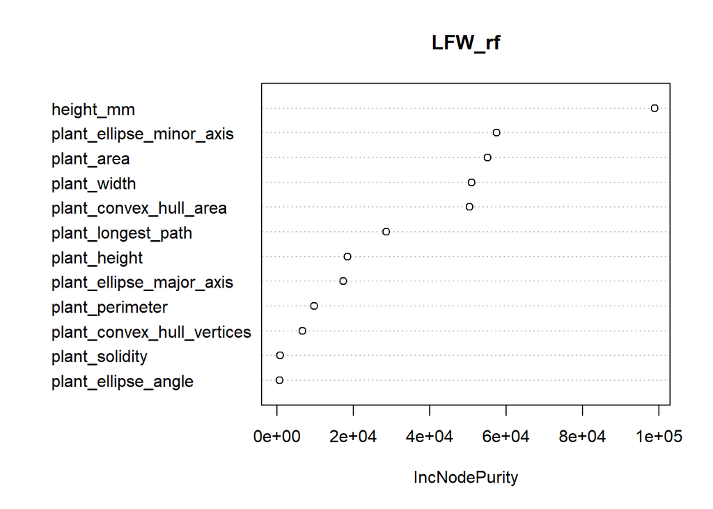

```r
varImpPlot(LFW_rf)
```

```r
LFW_rf
```

```
##
## Call:
##  randomForest(formula = LFW_g ~ ., data = train_set, ntree = 500)
##                Type of random forest: regression
##                      Number of trees: 500
## No. of variables tried at each split: 4
##
##           Mean of squared residuals: 103.8222
##                     % Var explained: 97.01
```

```r
sqrt(LFW_rf$mse[which.min(LFW_rf$mse)])
```

```
## [1] 9.669207
```

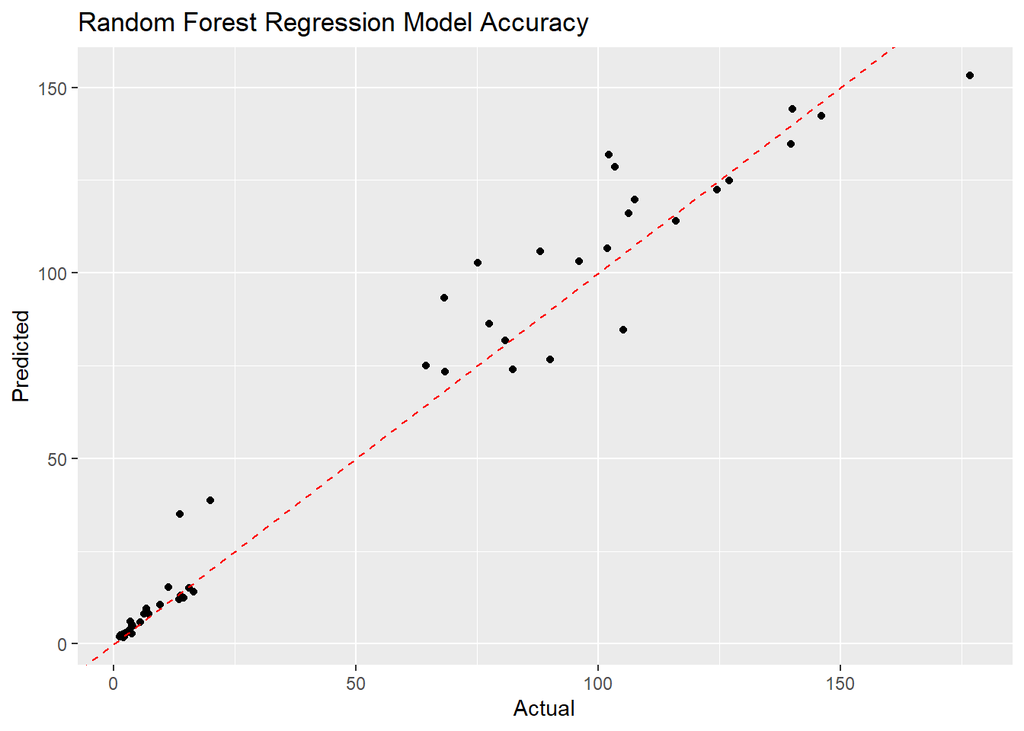

```r
ggplot(data.frame(actual = test_set$LFW_g, predicted = model_pred), aes(x = actual, y = predicted)) +
  geom_point() +
  geom_abline(slope = 1, intercept = 0, color = "red", linetype = "dashed") +
  labs(x = "Actual", y = "Predicted", title = "Random Forest Regression Model Accuracy")
```

Notice that the R-squared value obtained below is not the same as the R-quared given by the model’s summary. For this R-squared we are correlating the predicted values and the labels from the test set.

MSE displayed is not the same as the summary MSE neither. The MSE we are calculating here is mean squared error of the model’s prediction on the testing data. This metric measures how well the model generalizes to new, unseen data.

While the two MSE values are related, they are not the same. The out-of-bag MSE gives an estimate of the model’s generalization performance based on the training data, while the MSE on the test set provides an actual measure of how well the model performs on new, unseen data.

```r
# Evaluate the model performance: On new, unseen data.
MAE <- mean(abs(model_pred - test_set$LFW_g))
MSE <- mean((model_pred - test_set$LFW_g)^2)
R_squared <- cor(model_pred,test_set$LFW_g)^2
RMSE<- RMSE(model_pred,test_set$LFW_g)

# Print the performance metrics
cat("Mean Absolute Error (MAE): ", MAE, "\n")
```

```
## Mean Absolute Error (MAE):  6.740747
```

```r
cat("Mean Squared Error (MSE): ", MSE, "\n")
```

```
## Mean Squared Error (MSE):  117.8125
```

```r
cat("R-squared: ", R_squared, "\n")
```

```
## R-squared:  0.9611589
```

```r
cat("RMSE (Prediction): ", RMSE, "\n")
```

```
## RMSE (Prediction):  10.85415
```

Partial dependence plots show how each variable or predictor affects the model’s predictions.However, Partial dependence plots will have problems with highly correlated variables (like the ones we are including in our models).

A solution to deal with that correlation is using an Accumulated Local Effect (ALE) plot.

Relative importance of features

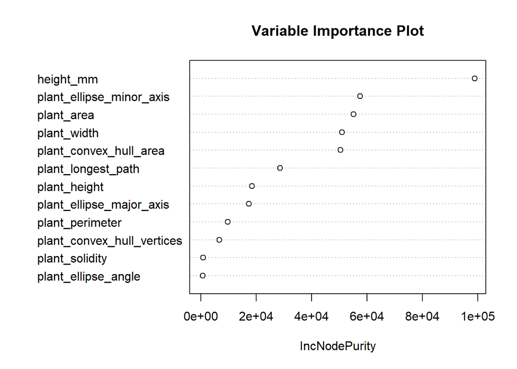

```r
LFW_importance <- importance(LFW_rf, type = 1)
varImpPlot(LFW_rf, main = "Variable Importance Plot")
```

```r
print(LFW_importance)
```

```
##
## height_mm
## plant_area
## plant_convex_hull_area
## plant_solidity
## plant_perimeter
## plant_width
## plant_height
## plant_longest_path
## plant_convex_hull_vertices
## plant_ellipse_major_axis
## plant_ellipse_minor_axis
## plant_ellipse_angle
```

#### LFW Selecting Variables

```r
# Use a random forest model to predict LFW, this time splitting the dataset.
set.seed(123)
train_id<- sample(1:nrow(img_LFW),0.7*nrow(img_LFW))
train_set<- img_LFW[train_id,]
test_set<- img_LFW[-train_id,]
```

### Estimation Leaf Dry Weight (LDW)

```r
# Use a random forest model to predict LFW, this time splitting the dataset.
set.seed(123)
train_id_LDW<- sample(1:nrow(img_LDW),0.7*nrow(img_LDW))
train_set_LDW<- img_LDW[train_id_LDW,]
test_set_LDW<- img_LDW[-train_id_LDW,]
```

Once we split the whole dataset we can run the Random Forest model using our train_data.

```r
LDW_rf <- randomForest(LDW_g~., data = train_set_LDW, ntree = 500)
```

Now all the predictions will be made on our test set.

```r
model_LDW <- predict(LDW_rf, newdata = test_set_LDW)
```

#### Model 1 Performance for LDW

The following chart shows the models summary

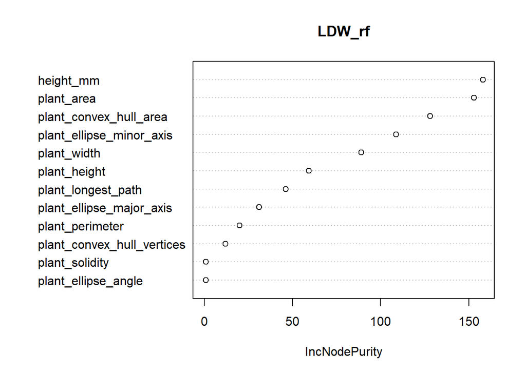

```r
varImpPlot(LDW_rf)
```

```r
LDW_rf
```

```
##
## Call:
##  randomForest(formula = LDW_g ~ ., data = train_set_LDW, ntree = 500)
##                Type of random forest: regression
##                      Number of trees: 500
## No. of variables tried at each split: 4
##
##           Mean of squared residuals: 0.1548017
##                     % Var explained: 97.82
```

```r
sqrt(LDW_rf$mse[which.min(LDW_rf$mse)])
```

```
## [1] 0.3912972
```

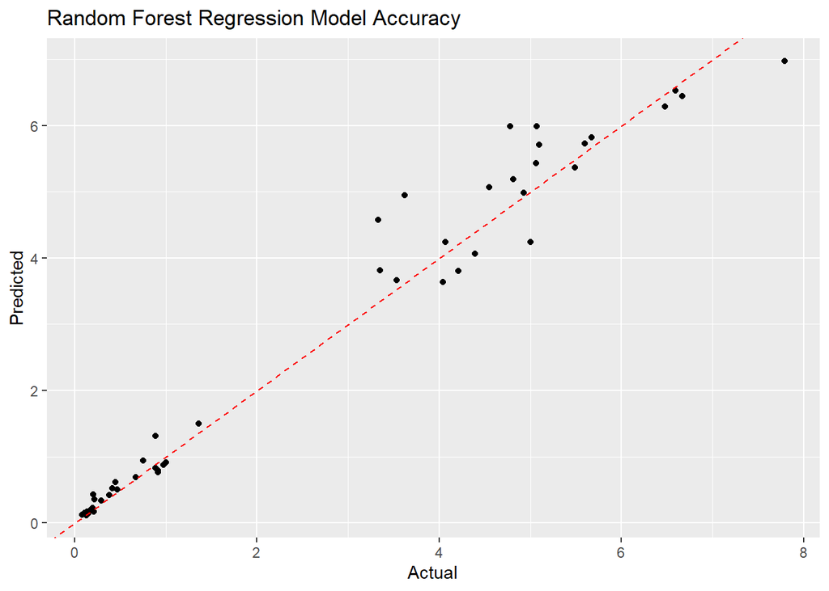

```r
ggplot(data.frame(actual = test_set_LDW$LDW_g, predicted = model_LDW), aes(x = actual, y = predicted)) +
  geom_point() +
  geom_abline(slope = 1, intercept = 0, color = "red", linetype = "dashed") +
  labs(x = "Actual", y = "Predicted", title = "Random Forest Regression Model Accuracy")
```

```r
# Evaluate the model performance
MAE <- mean(abs(model_LDW - test_set_LDW$LDW_g))
MSE <- mean((model_LDW - test_set_LDW$LDW_g)^2)
R_squared <- cor(model_LDW,test_set_LDW$LDW_g)^2

# Print the performance metrics
cat("Mean Absolute Error (MAE): ", MAE, "\n")
```

```
## Mean Absolute Error (MAE):  0.2659551
```

```r
cat("Mean Squared Error (MSE): ", MSE, "\n")
```

```
## Mean Squared Error (MSE):  0.1805397
```

```r
cat("R-squared: ", R_squared, "\n")
```

```
## R-squared:  0.9714714
```

### Estimation Leaf Area (LA)

```r
# Use a random forest model to predict LFW, this time splitting the dataset.
set.seed(123)
train_id_LA<- sample(1:nrow(img_LA),0.7*nrow(img_LA))
train_set_LA<- img_LA[train_id_LA,]
test_set_LA<- img_LA[-train_id_LA,]
```

Once we split the whole dataset we can run the Random Forest model using our train_data.

```r
LA_rf <- randomForest(LA_mm2~., data = train_set_LA, ntree = 500)
```

Now all the predictions will be made on our test set.

```r
model_LA <- predict(LA_rf, newdata = test_set_LA)
```

The following chart shows the models summary

#### Model 1 Performance for LA

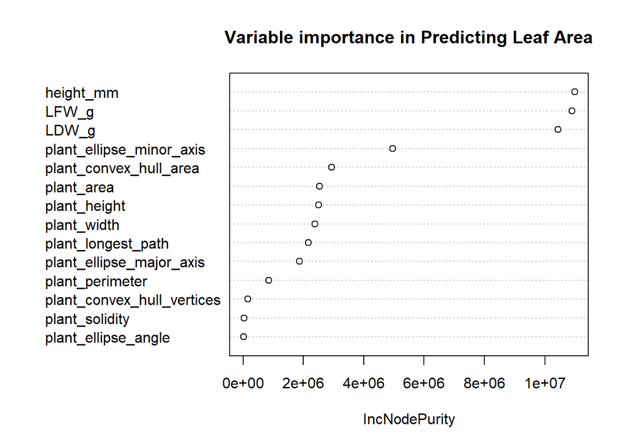

```r
varImpPlot(LA_rf, main = "Variable importance in Predicting Leaf Area")
```

```r
LA_rf
```

```
##
## Call:
##  randomForest(formula = LA_mm2 ~ ., data = train_set_LA, ntree = 500)
##                Type of random forest: regression
##                      Number of trees: 500
## No. of variables tried at each split: 4
##
##           Mean of squared residuals: 3650.379
##                     % Var explained: 99.21
```

```r
sqrt(LA_rf$mse[which.min(LA_rf$mse)]) # Raw calculation of RMSE
```

```
## [1] 44.29631
```

```r
RMSE(model_LA,test_set_LA$LA_mm2) # using caret functions
```

```
## [1] 56.1439
```

```r
R2(model_LA,test_set_LA$LA_mm2)
```

```
## [1] 0.991731
```

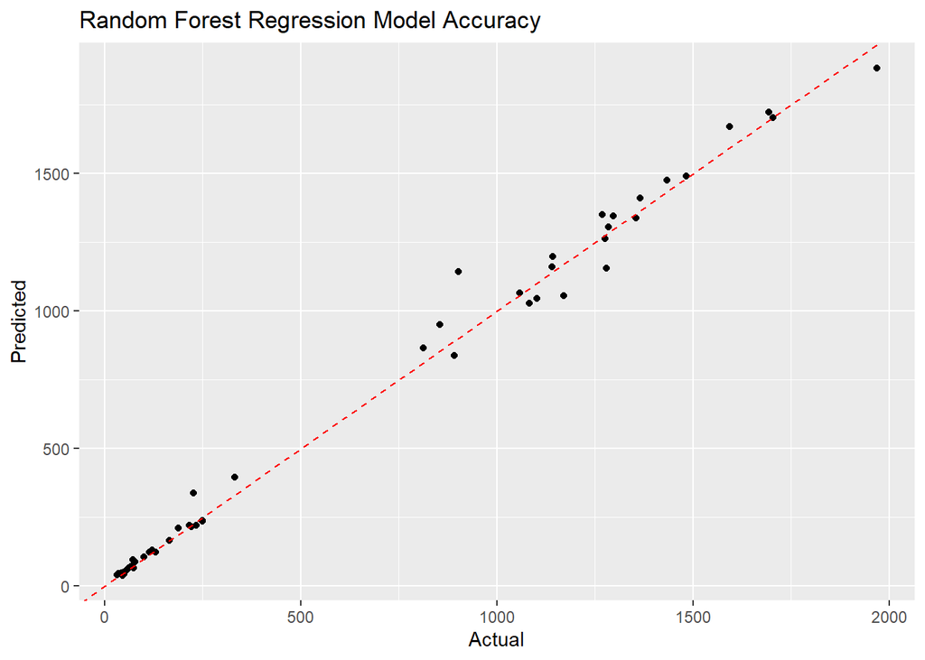

```r
ggplot(data.frame(actual = test_set_LA$LA_mm2, predicted = model_LA), aes(x = actual, y = predicted)) +
  geom_point() +
  geom_abline(slope = 1, intercept = 0, color = "red", linetype = "dashed") +
  labs(x = "Actual", y = "Predicted", title = "Random Forest Regression Model Accuracy")
```

```r
# Evaluate the model performance
MAE <- mean(abs(model_LA - test_set_LA$LA_mm2))
MSE <- mean((model_LA - test_set_LA$LA_mm2)^2)
R_squared <- cor(model_LA,test_set_LA$LA_mm2)^2

# Print the performance metrics
cat("Mean Absolute Error (MAE): ", MAE, "\n")
```

```
## Mean Absolute Error (MAE):  34.53968
```

```r
cat("Mean Squared Error (MSE): ", MSE, "\n")
```

```
## Mean Squared Error (MSE):  3152.137
```

```r
cat("R-squared: ", R_squared, "\n")
```

```
## R-squared:  0.991731
```

## Predictions Filtered By Harvest Date

From here, I’ll filter the information of our entire dataset by date to assess the model’s performance in each harvest date. In this scenario, the predict function will take as parameter the data set with an specific date. Lets start with the first harvest date

```r
LFW_h1 <- raw_data %>% filter(date == "02/02/2023") %>% dplyr::select(7,12:23) #3
```

Predicition of LFW for first harvest date using random forest model:

```r
h1_pred <- predict(LFW_rf, newdata = LFW_h1)
```

```r
# Evaluate the model performance
mean_h1 <- mean(h1_pred)
MAE <- mean(abs(h1_pred - LFW_h1$LFW_g))
MSE <- mean((h1_pred - LFW_h1$LFW_g)^2)
R_squared <- cor(h1_pred,LFW_h1$LFW_g)^2
RMSE<-RMSE(h1_pred,LFW_h1$LFW_g) # using caret functions
R_sqrd<- R2(h1_pred,LFW_h1$LFW_g) # same as cor(h3_pred,LFW_h3$LFW_g)^2
mean_LFW_h1 <- mean(LFW_h1$LFW_g)
sd_LFW_h1 <- sd(LFW_h1$LFW_g)

# Print the performance metrics
cat("Mean Absolute Error (MAE): ", MAE, "\n")
```

```
## Mean Absolute Error (MAE):  0.3997442
```

```r
cat("Mean Squared Error (MSE): ", MSE, "\n")
```

```
## Mean Squared Error (MSE):  0.412073
```

```r
cat("R-squared: ", R_sqrd, "\n")
```

```
## R-squared:  0.5808694
```

```r
cat("RMSE (Prediction): ", RMSE, "\n") # same as sqrt(MSE)
```

```
## RMSE (Prediction):  0.6419291
```

```r
cat("Average H2 (LFW): ", mean_LFW_h1, "\n")
```

```
## Average H2 (LFW):  2.594848
```

```r
cat("Standard deviation H2 (LFW)): ", sd_LFW_h1, "\n")
```

```
## Standard deviation H2 (LFW)):  0.7406421
```

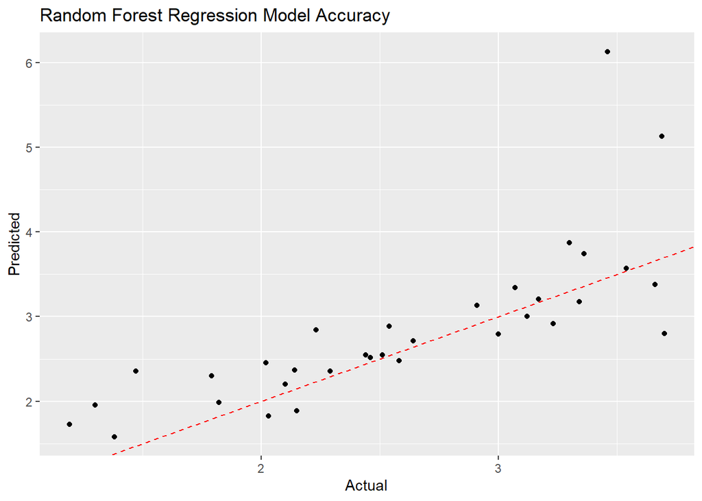

```r
ggplot(data.frame(actual = LFW_h1$LFW_g, predicted = h1_pred), aes(x = actual, y = predicted)) +
  geom_point() +
  geom_abline(slope = 1, intercept = 0, color = "red", linetype = "dashed") +
  labs(x = "Actual", y = "Predicted", title = "Random Forest Regression Model Accuracy")
```

Now, we will do the same for our second harvest date.

```r
LFW_h2 <- raw_data %>% filter(date == "09/02/2023") %>% dplyr::select(7,12:23) #3
```

```r
h2_pred <- predict(LFW_rf, newdata = LFW_h2)
```

Lets check the performance of the random forest model for the data obtained for our second harvest:

```r
# Evaluate the model performance
MAE <- mean(abs(h2_pred - LFW_h2$LFW_g))
MSE <- mean((h2_pred - LFW_h2$LFW_g)^2)
RMSE<-RMSE(h2_pred,LFW_h2$LFW_g) # using caret functions
R_sqrd<- R2(h2_pred,LFW_h2$LFW_g) # same as cor(h3_pred,LFW_h3$LFW_g)^2
mean_LFW_h2 <- mean(LFW_h2$LFW_g)
sd_LFW_h2 <- sd(LFW_h2$LFW_g)

# Print the performance metrics
cat("Mean Absolute Error (MAE): ", MAE, "\n")
```

```
## Mean Absolute Error (MAE):  1.658769
```

```r
cat("Mean Squared Error (MSE): ", MSE, "\n")
```

```
## Mean Squared Error (MSE):  17.48488
```

```r
cat("R-squared: ", R_sqrd, "\n")
```

```
## R-squared:  0.5721
```

```r
cat("RMSE (Prediction): ", RMSE, "\n") # same as sqrt(MSE)
```

```
## RMSE (Prediction):  4.181492
```

```r
cat("Average H2 (LFW): ", mean_LFW_h2, "\n")
```

```
## Average H2 (LFW):  10.40529
```

```r
cat("Standard deviation H2 (LFW)): ", sd_LFW_h2, "\n")
```

```
## Standard deviation H2 (LFW)):  3.905721
```

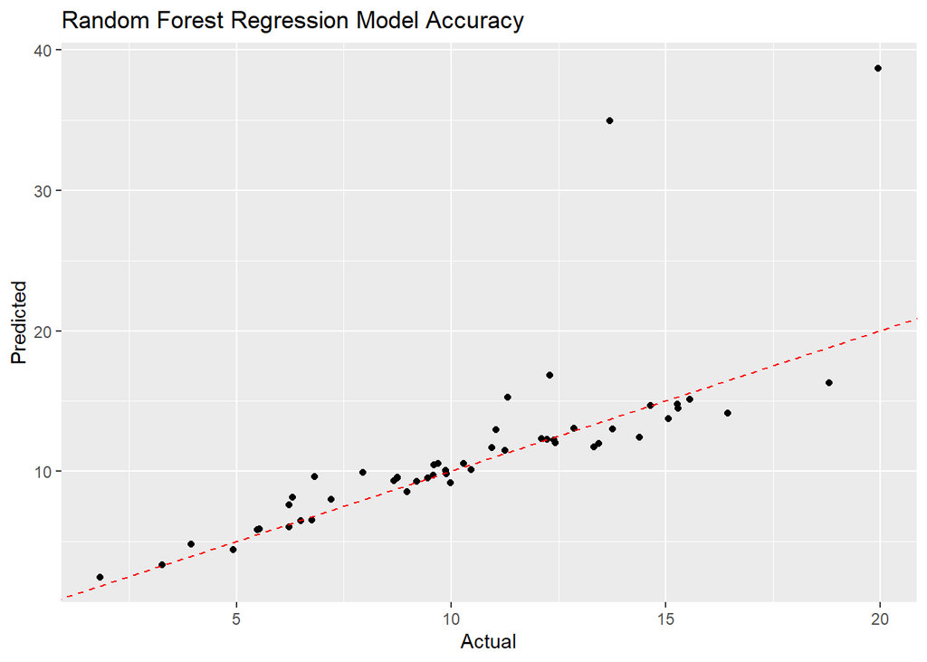

```r
ggplot(data.frame(actual = LFW_h2$LFW_g, predicted = h2_pred), aes(x = actual, y = predicted)) +
  geom_point() +
  geom_abline(slope = 1, intercept = 0, color = "red", linetype = "dashed") +
  labs(x = "Actual", y = "Predicted", title = "Random Forest Regression Model Accuracy")
```

```r
LFW_h3 <- raw_data %>% filter(date == "23/02/2023") %>% dplyr::select(7,12:23) #3
```

```r
h3_pred <- predict(LFW_rf, newdata = LFW_h3)
```

```r
# Evaluate the model performance
MAE <- mean(abs(h3_pred - LFW_h3$LFW_g))
MSE <- mean((h3_pred - LFW_h3$LFW_g)^2)
RMSE<-RMSE(h3_pred,LFW_h3$LFW_g) # using caret functions
R_sqrd<- R2(h3_pred,LFW_h3$LFW_g) # same as cor(h3_pred,LFW_h3$LFW_g)^2
mean_LFW <- mean(LFW_h3$LFW_g)
sd_LFW <- sd(LFW_h3$LFW_g)

# Print the performance metrics
cat("Mean Absolute Error (MAE): ", MAE, "\n")
```

```
## Mean Absolute Error (MAE):  6.62047
```

```r
cat("Mean Squared Error (MSE): ", MSE, "\n")
```

```
## Mean Squared Error (MSE):  89.48668
```

```r
cat("R-squared: ", R_sqrd, "\n")
```

```
## R-squared:  0.8941423
```

```r
cat("RMSE (Prediction): ", RMSE, "\n") # same as sqrt(MSE)
```

```
## RMSE (Prediction):  9.45974
```

```r
cat("Average (LFW): ", mean_LFW, "\n")
```

```
## Average (LFW):  114.5844
```

```r
cat("Standard deviation (LFW)): ", sd_LFW, "\n")
```

```
## Standard deviation (LFW)):  28.11278
```

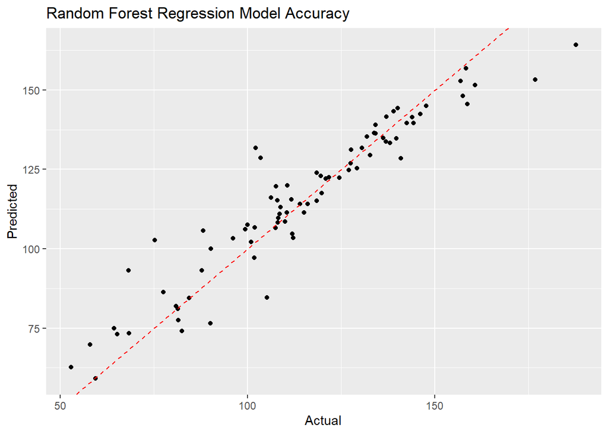

```r
ggplot(data.frame(actual = LFW_h3$LFW_g, predicted = h3_pred), aes(x = actual, y = predicted)) +
  geom_point() +
  geom_abline(slope = 1, intercept = 0, color = "red", linetype = "dashed") +
  labs(x = "Actual", y = "Predicted", title = "Random Forest Regression Model Accuracy")
```

```r
LA_h3 <- raw_data %>% filter(date == "23/02/2023") %>% dplyr::select(7,8,9,12:23) #3
```

```r
LAh3_pred <- predict(LA_rf, newdata = LA_h3)
```

```r
# Evaluate the model performance
MAE <- mean(abs(LAh3_pred - LA_h3$LA_mm2))
MSE <- mean((LAh3_pred - LA_h3$LA_mm2)^2)
R_squared <- cor(LAh3_pred, LA_h3$LA_mm2)^2

# Print the performance metrics
cat("Mean Absolute Error (MAE): ", MAE, "\n")
```

```
## Mean Absolute Error (MAE):  32.78282
```

```r
cat("Mean Squared Error (MSE): ", MSE, "\n")
```

```
## Mean Squared Error (MSE):  2688.225
```

```r
cat("R-squared: ", R_squared, "\n")
```

```
## R-squared:  0.9702097
```

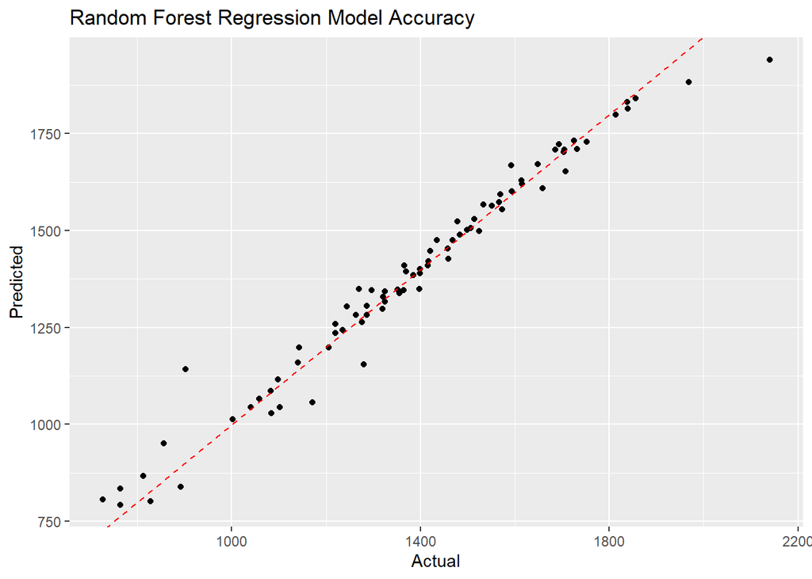

```r
ggplot(data.frame(actual = LA_h3$LA_mm2, predicted = LAh3_pred), aes(x = actual, y = predicted)) +
  geom_point() +
  geom_abline(slope = 1, intercept = 0, color = "red", linetype = "dashed") +
  labs(x = "Actual", y = "Predicted", title = "Random Forest Regression Model Accuracy")
```

```r
sqrt(MSE)
```

```
## [1] 51.8481
```

```r
print(mean(LA_h3$LA_mm2))
```

```
## [1] 1382.459
```

```r
print(sd(LA_h3$LA_mm2))
```

```
## [1] 293.5194
```

Now lets apply the same strategy for Leaf Dry Weight (LDW). We will split dataset by date to check how our Random Forest model performs in the last harvest date.

```r
LDW_h3 <- raw_data %>% filter(date == "23/02/2023") %>% dplyr::select(8,12:23) #3
```

```r
LDWh3_pred <- predict(LDW_rf, newdata = LDW_h3)
```

```r
# Evaluate the model performance: Don't forget to display the mean of the observed values (labels).
MAE <- mean(abs(LDWh3_pred - LDW_h3$LDW_g))
MSE <- mean((LDWh3_pred - LDW_h3$LDW_g)^2)
R_pearson <- cor(LDWh3_pred, LDW_h3$LDW_g)
R_squared <- cor(LDWh3_pred, LDW_h3$LDW_g)^2
RMSE<- RMSE(LDWh3_pred,LDW_h3$LDW_g)


# Print the performance metrics
cat("Mean Absolute Error (MAE): ", MAE, "\n")
```

```
## Mean Absolute Error (MAE):  0.2608947
```

```r
cat("Mean Squared Error (MSE): ", MSE, "\n")
```

```
## Mean Squared Error (MSE):  0.1499115
```

```r
cat("Pearson Correlation: ", R_pearson, "\n")
```

```
## Pearson Correlation:  0.9428539
```

```r
cat("R-squared: ", R_squared, "\n")
```

```
## R-squared:  0.8889735
```

```r
cat("RMSE ", RMSE, "\n")
```

```
## RMSE  0.387184
```

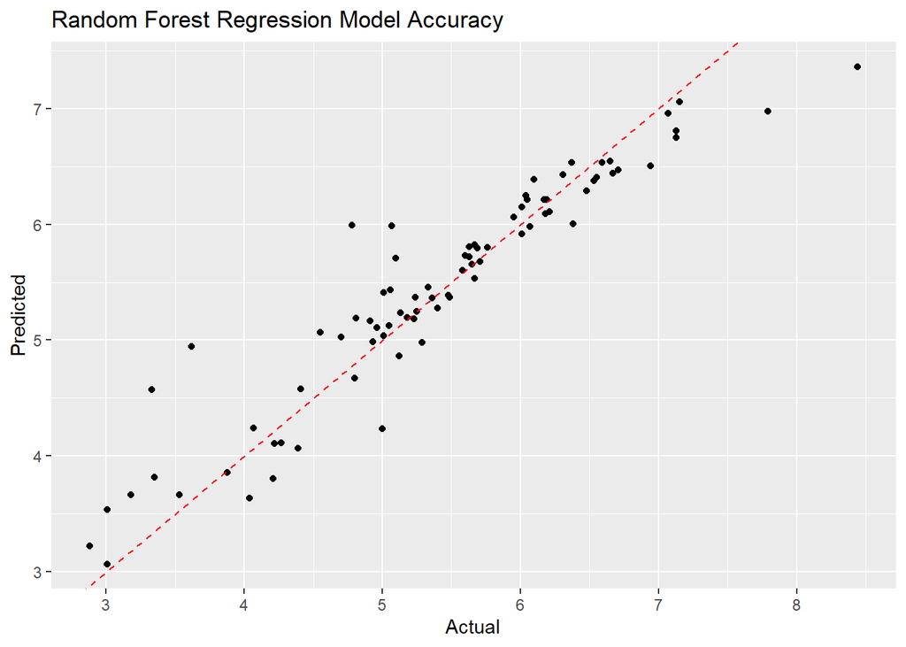

```r
ggplot(data.frame(actual = LDW_h3$LDW_g, predicted = LDWh3_pred), aes(x = actual, y = predicted)) +
  geom_point() +
  geom_abline(slope = 1, intercept = 0, color = "red", linetype = "dashed") +
  labs(x = "Actual", y = "Predicted", title = "Random Forest Regression Model Accuracy")
```

```r
print(sqrt(MSE))
```

```
## [1] 0.387184
```

```r
print(mean(LDW_h3$LDW_g))
```

```
## [1] 5.396296
```

```r
print(sd(LDW_h3$LDW_g))
```

```
## [1] 1.129162
```

```r
RMSE(LDWh3_pred,LDW_h3$LDW_g)
```

```
## [1] 0.387184
```

```r
R2(LDWh3_pred,LDW_h3$LDW_g)
```

```
## [1] 0.8889735
```